# Lab3_rng_streams

Eric Zhao

2023-02-01

### Prep

```r
#function built
myArr1<-function(){rexp(1, 1)}
myArr2<-function(){rexp(1, 11/10)}
mySvc1<-function(){rexp(1, 10/9)}

#simulation
output11<-ssq(maxArrivals = 20, interarrivalFcn = myArr1, serviceFcn = mySvc1, seed = 8675309, saveAllStats = TRUE, showOutput = FALSE)

output12<-ssq(maxArrivals = 20, interarrivalFcn = myArr2, serviceFcn = mySvc1, seed = 8675309, saveAllStats = TRUE, showOutput = FALSE)
```

### Results

```r
print(output11$interarrivalTimes)
```

```
##  [1] 1.66216344 1.22326524 0.34609182 0.67646507 0.02190231 0.49897147
##  [7] 0.14296101 0.43171886 3.00313699 2.34623787 0.63278097 1.85741936
## [13] 2.01721600 0.35873818 3.01868395 1.47366193 0.52454877 0.97513225
## [19] 0.93961356 1.58288361
```

```r
print(output12$interarrivalTimes)
```

```
##  [1] 1.51105767 1.11205931 0.31462893 0.61496825 0.01991119 0.45361043
##  [7] 0.12996455 0.57621243 0.10845545 0.30812606 0.64700100 2.13294351
## [13] 0.57525543 0.20751338 1.68856306 0.40275308 0.32612562 0.96832497
## [19] 0.87779602 1.33969266
```

```r
print(output11$serviceTimes)
```

```
##  [1] 0.6906071 0.2777054 0.1499705 0.6604378 0.5704503 0.1073709 0.3050448
##  [8] 0.6405310 1.4994352 0.2054382 0.8472361 0.3987256 0.9586417 0.8690181
## [15] 0.9447208 0.4549870 0.3656762 0.7658315 0.2638980 0.4963474
```

```r
print(output12$serviceTimes)
```

```
##  [1] 0.6906071 0.2777054 0.1499705 0.6604378 0.3885470 2.7028233 1.4994352
##  [8] 0.8472361 1.8154944 2.7168156 0.9447208 0.4549870 0.8776190 0.3656762
## [15] 0.8456522 0.7658315 1.4245953 0.2638980 0.7124820 0.4963474
```

#### Q1

The first ten service times from first run are:

```r
output11$serviceTimes[1:10]
```

```
##  [1] 0.6906071 0.2777054 0.1499705 0.6604378 0.5704503 0.1073709 0.3050448
##  [8] 0.6405310 1.4994352 0.2054382
```

#### Q2

The first ten service times from second run are:

```r
output12$serviceTimes[1:10]
```

```
##  [1] 0.6906071 0.2777054 0.1499705 0.6604378 0.3885470 2.7028233 1.4994352
##  [8] 0.8472361 1.8154944 2.7168156
```

#### Q3

The divergence starts from the fifth customer and the service times for each customer are: 0.5704503 and 0.3885470.

#### skylineplots

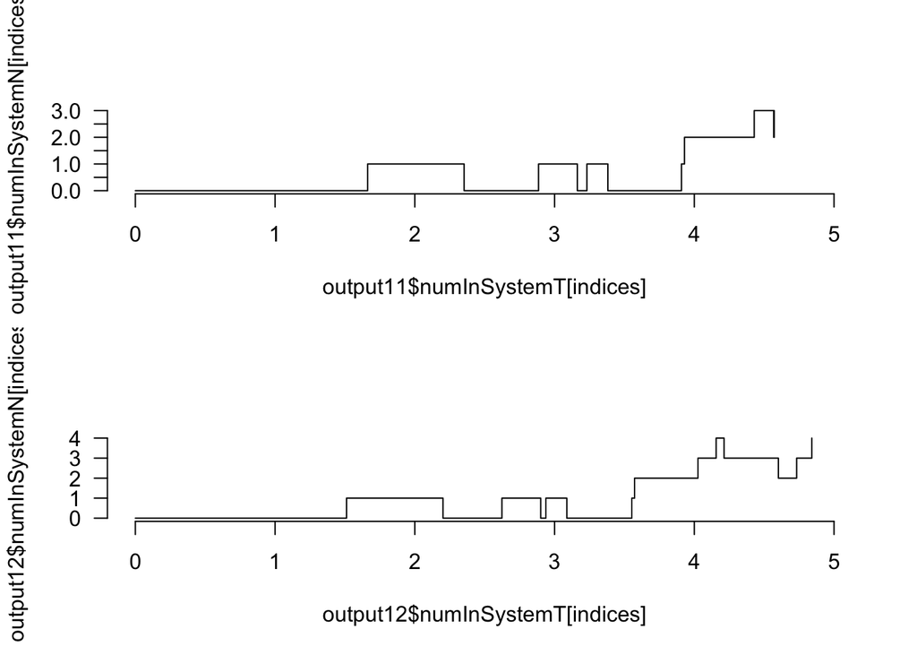

```r
par(mfrow=c(2,1))

indices<-seq_along(output11$numInSystemT[output11$numInSystemT<=5])
plot(output11$numInSystemT[indices], output11$numInSystemN[indices], type="s", xlim=c(0, 5), bty="n", las=1)

indices<-seq_along(output12$numInSystemT[output12$numInSystemT<=5])
plot(output12$numInSystemT[indices], output12$numInSystemN[indices], type="s", xlim=c(0, 5), bty="n", las=1)
```

#### Q4

According to the skyplots, we know that there are two arrivals after the fourth arrival occur before the fourth customer’s service is finished.

#### Q5

In the second run, we can observe that there are three more arrivals after the fourth arrival before that fourth customer complete the services.

#### Add 4th completion time

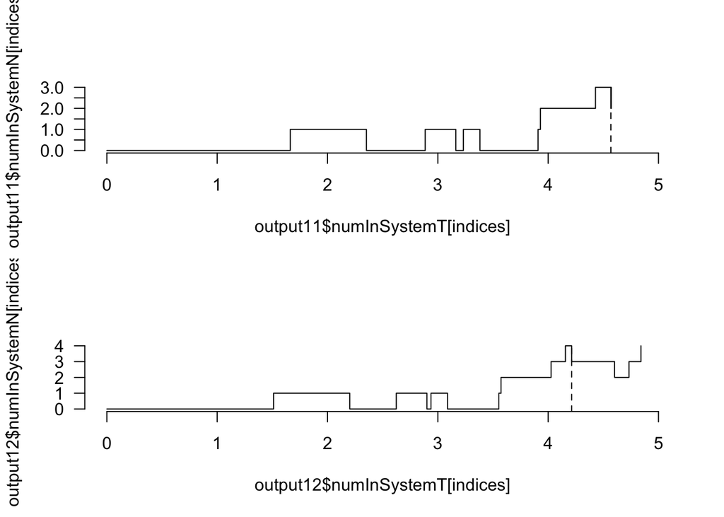

```r
par(mfrow=c(2,1))

arrivalTimes<-cumsum(output11$interarrivalTimes)
completitionTimes<-arrivalTimes+output11$sojournTimes
indices<-seq_along(output11$numInSystemT[output11$numInSystemT<=5])
plot(output11$numInSystemT[indices], output11$numInSystemN[indices], type="s", xlim=c(0, 5), bty="n", las=1)
abline(v=completitionTimes[4], lty=2)

arrivalTimes<-cumsum(output12$interarrivalTimes)
completitionTimes<-arrivalTimes+output12$sojournTimes
indices<-seq_along(output12$numInSystemT[output12$numInSystemT<=5])
plot(output12$numInSystemT[indices], output12$numInSystemN[indices], type="s", xlim=c(0, 5), bty="n", las=1)
abline(v=completitionTimes[4], lty=2)
```

### RNG_Streams

```r
set.seed(8675309)
#The first three numbers (rate = 1) are interarrivals, the second three (rate = 10/9) are service times.
rexp(1, 1)
```

```
## [1] 1.662163
```

```r
rexp(1, 1)
```

```
## [1] 1.223265
```

```r
rexp(1, 1)
```

```
## [1] 0.7673412
```

```r
rexp(1, 10/9)
```

```
## [1] 0.3114826
```

```r
rexp(1, 10/9)
```

```
## [1] 0.2777054
```

```r
rexp(1, 10/9)
```

```
## [1] 0.6088186
```

#### Q6

The arrival times(cumulative interarrival times) are 1.662, 2.885 and 3.653.

#### Q7

The service times are 0.311, 0.278 and 0.609.

```r
set.seed(8675309)
#The first three numbers (rate = 1) are interarrivals, the second three (rate = 10/9) are service times.
rexp(1, 1)
```

```
## [1] 1.662163
```

```r
rexp(1, 10/9)
```

```
## [1] 1.100939
```

```r
rexp(1, 1)
```

```
## [1] 0.7673412
```

```r
rexp(1, 10/9)
```

```
## [1] 0.3114826
```

```r
rexp(1, 1)
```

```
## [1] 0.3085615
```

```r
rexp(1, 10/9)
```

```
## [1] 0.6088186
```

#### Q8

The arrival times are 1.6622, 2.4295 and 2.7381.

#### Q9

The service times are 1.1009, 0.3115 and 0.6088.

#### using vexp()

```r
set.seed(8675309)

#repeat the exercise using vexp rather than rexp, and use stream 1 for interarrivals and stream 2 for service times:
vexp(1, 1, stream = 1)
```

```
## [1] 0.2334595
```

```r
vexp(1, 1, stream = 1)
```

```
## [1] 1.07828
```

```r
vexp(1, 1, stream = 1)
```

```
## [1] 0.7855611
```

```r
vexp(1, 10/9, stream = 2)
```

```
## [1] 0.0305915
```

```r
vexp(1, 10/9, stream = 2)
```

```
## [1] 0.1224158
```

```r
vexp(1, 10/9, stream = 2)
```

```
## [1] 1.42499
```

#### Q10

The arrival times are 0.2335, 1.3117 and 2.0973.

#### Q11

The service times are 0.0306, 0.1224 and 1.4250.

#### interleave the time generation

```r
set.seed(8675309)

vexp(1, 1, stream = 1)
```

```
## [1] 0.2334595
```

```r
vexp(1, 10/9, stream = 2)
```

```
## [1] 0.0305915
```

```r
vexp(1, 1, stream = 1)
```

```
## [1] 1.07828
```

```r
vexp(1, 10/9, stream = 2)
```

```
## [1] 0.1224158
```

```r
vexp(1, 1, stream = 1)
```

```
## [1] 0.7855611
```

```r
vexp(1, 10/9, stream = 2)
```

```
## [1] 1.42499
```

#### Q12

The arrival times are 0.23346, 1.31174 and 2.0973.

#### Q13

The service times are 0.0306, 0.1224 and 1.4250.

### Return the simulation

#### Redefine process functions with streams

```r
myArr1<-function(){vexp(1, 1, stream = 1)}
myArr2<-function(){vexp(1, 11/10, stream = 1)}
mySvc1<-function(){vexp(1, 10/9, stream = 2)}
```

#### Simulation again

```r
#simulation with different arrival processes
output11<-ssq(maxArrivals = 20, interarrivalFcn = myArr1, serviceFcn = mySvc1, seed = 8675309, saveAllStats = TRUE, showOutput = FALSE)

output12<-ssq(maxArrivals = 20, interarrivalFcn = myArr2, serviceFcn = mySvc1, seed = 8675309, saveAllStats = TRUE, showOutput = FALSE)
```

#### interarrival and service time

```r
output11$interarrivalTimes
```

```
##  [1] 0.23345951 1.07828020 0.78556111 0.35311660 0.90501100 2.42985756
##  [7] 0.47442318 0.01652069 1.50555953 0.49710849 0.74338402 0.35126435
## [13] 2.16909893 2.85546077 0.02080979 0.70771366 1.22571701 0.34982305
## [19] 0.64498544 0.20104739
```

```r
output11$serviceTimes
```

```
##  [1] 0.03059150 0.12241584 1.42498986 4.55083122 2.49443812 0.21221607
##  [7] 0.09939047 0.52513160 1.35447248 0.14203867 0.53753282 0.65148306
## [13] 2.43953310 0.42059015 0.80551067 0.25625162 0.04951228 0.02394590
## [19] 1.96568156 0.84102916
```

```r
output12$interarrivalTimes
```

```
##  [1] 0.21223592 0.98025473 0.71414646 0.32101509 0.82273727 2.20896142
##  [7] 0.43129380 0.01501881 1.36869049 0.45191681 0.67580365 0.31933123
## [13] 1.97190812 2.59587343 0.01891799 0.64337606 1.11428819 0.31802095
## [19] 0.58635040 0.18277035
```

```r
output12$serviceTimes
```

```
##  [1] 0.03059150 0.12241584 1.42498986 4.55083122 2.49443812 0.21221607
##  [7] 0.09939047 0.52513160 1.35447248 0.14203867 0.53753282 0.65148306
## [13] 2.43953310 0.42059015 0.80551067 0.25625162 0.04951228 0.02394590
## [19] 1.96568156 0.84102916
```

#### Q14

```r
sum(output11$interarrivalTimes-output12$interarrivalTimes)
```

```
## [1] 1.595291
```

#### Q15

```r
sum(output11$serviceTimes-output12$serviceTimess)
```

```
## [1] 0
```

#### Rerun simulation

```r
mySvc2<-function(){vexp(1, 11/10, stream = 2)}
#simulation with different service processes
output11<-ssq(maxArrivals = 20, interarrivalFcn = myArr1, serviceFcn = mySvc1, seed = 8675309, saveAllStats = TRUE, showOutput = FALSE)

output12<-ssq(maxArrivals = 20, interarrivalFcn = myArr1, serviceFcn = mySvc2, seed = 8675309, saveAllStats = TRUE, showOutput = FALSE)
```

#### same interarrival and different service time processes

```r
output11$interarrivalTimes
```

```
##  [1] 0.23345951 1.07828020 0.78556111 0.35311660 0.90501100 2.42985756
##  [7] 0.47442318 0.01652069 1.50555953 0.49710849 0.74338402 0.35126435
## [13] 2.16909893 2.85546077 0.02080979 0.70771366 1.22571701 0.34982305
## [19] 0.64498544 0.20104739
```

```r
output11$serviceTimes
```

```
##  [1] 0.03059150 0.12241584 1.42498986 4.55083122 2.49443812 0.21221607
##  [7] 0.09939047 0.52513160 1.35447248 0.14203867 0.53753282 0.65148306
## [13] 2.43953310 0.42059015 0.80551067 0.25625162 0.04951228 0.02394590
## [19] 1.96568156 0.84102916
```

```r
output12$interarrivalTimes
```

```
##  [1] 0.23345951 1.07828020 0.78556111 0.35311660 0.90501100 2.42985756
##  [7] 0.47442318 0.01652069 1.50555953 0.49710849 0.74338402 0.35126435
## [13] 2.16909893 2.85546077 0.02080979 0.70771366 1.22571701 0.34982305
## [19] 0.64498544 0.20104739
```

```r
output12$serviceTimes
```

```
##  [1] 0.03090051 0.12365236 1.43938370 4.59679921 2.51963447 0.21435967
##  [7] 0.10039441 0.53043596 1.36815402 0.14347341 0.54296244 0.65806369
## [13] 2.46417485 0.42483854 0.81364714 0.25884002 0.05001240 0.02418777
## [19] 1.98553692 0.84952440
```